```python
import numpy as np
import pandas as pd
from sklearn.cluster import KMeans
from sklearn.neighbors import KNeighborsClassifier
from sklearn.tree import DecisionTreeClassifier
from sklearn.preprocessing import LabelEncoder
import matplotlib.pyplot as plt
import seaborn as sns
from sklearn import cluster
%matplotlib inline
```

# I/ Descriptive analysis

## OBJECTIVE 1.1: Identify the most profitable operations

### 1/ K-Means Method

```python
#import fichiers csv
Operation_Amount = pd.read_csv("Operation_Amount.csv")
Operation_Amount.head()
```

|  | mp_Operation_PK | Amount |
| --- | --- | --- |
| 0 | 58 | 0.0 |
| 1 | 58 | 0.0 |
| 2 | 58 | 0.0 |
| 3 | 58 | 0.0 |
| 4 | 58 | 0.0 |

```python
Operation_Amount.describe()
```

|  | mp_Operation_PK | Amount |
| --- | --- | --- |
| count | 3.614193e+07 | 3.614193e+07 |
| mean | 5.616604e+01 | 1.382287e+05 |
| std | 9.381659e+00 | 8.288364e+06 |
| min | 1.000000e+00 | 0.000000e+00 |
| 25% | 5.300000e+01 | 0.000000e+00 |
| 50% | 5.800000e+01 | 0.000000e+00 |
| 75% | 5.800000e+01 | 0.000000e+00 |
| max | 1.110000e+02 | 2.000000e+10 |

```python
cible=Operation_Amount.iloc[6404331:6404800,0:2]
```

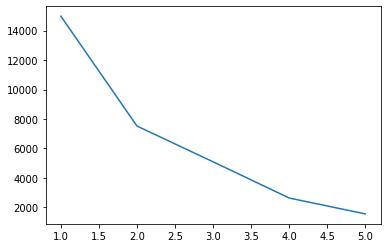

```python
import matplotlib.pyplot as plt
from sklearn.cluster import KMeans
wcss = []
for i in range(1,6):
    model=KMeans(n_clusters=i,init='k-means++')
    model.fit(cible)
    wcss.append(model.inertia_)
plt.plot(range(1,6),wcss)
```

```python
kmeans=cluster.KMeans(n_clusters=2)
kmeans.fit(cible)
```

```
KMeans(algorithm='auto', copy_x=True, init='k-means++', max_iter=300,
       n_clusters=2, n_init=10, n_jobs=None, precompute_distances='auto',
       random_state=None, tol=0.0001, verbose=0)
```

```python
kmeans.cluster_centers_
```

```
array([[ 6.06405229e+01,  1.16339869e+00],
       [ 5.23496933e+01, -1.88737914e-15]])
```

```python
kmeans.labels_
```

```
array([1, 1, 1, 1, 1, 1, 1, 1, 1, 1, 1, 1, 1, 1, 1, 1, 1, 1, 1, 1, 1, 1,
       1, 1, 1, 1, 1, 1, 1, 1, 1, 1, 1, 1, 1, 1, 1, 1, 1, 1, 1, 1, 1, 1,
       1, 1, 1, 1, 1, 1, 1, 1, 1, 1, 1, 1, 1, 1, 1, 1, 1, 1, 1, 1, 1, 1,
       1, 1, 1, 1, 1, 1, 1, 1, 1, 1, 1, 1, 1, 1, 1, 1, 1, 1, 1, 1, 1, 1,
       1, 1, 1, 1, 1, 1, 1, 1, 1, 1, 1, 1, 1, 1, 1, 1, 1, 1, 1, 1, 1, 1,
       1, 1, 1, 0, 0, 0, 0, 0, 0, 0, 0, 0, 0, 0, 0, 0, 0, 0, 0, 0, 0, 0,
       0, 0, 0, 0, 0, 0, 0, 0, 0, 0, 0, 0, 0, 0, 0, 0, 0, 0, 0, 0, 0, 0,
       0, 0, 0, 0, 0, 0, 0, 0, 0, 0, 0, 0, 0, 0, 0, 0, 0, 0, 0, 0, 0, 0,
       0, 0, 0, 0, 0, 0, 0, 0, 0, 0, 0, 0, 0, 0, 0, 0, 0, 0, 0, 0, 0, 0,
       0, 0, 0, 0, 0, 0, 0, 0, 0, 0, 0, 0, 0, 0, 0, 0, 0, 0, 0, 0, 0, 0,
       0, 0, 0, 0, 0, 0, 0, 0, 0, 0, 0, 0, 0, 0, 0, 0, 0, 0, 0, 0, 0, 0,
       0, 0, 0, 0, 0, 0, 0, 0, 0, 0, 0, 0, 0, 0, 0, 0, 0, 0, 0, 0, 0, 0,
       0, 0, 0, 0, 0, 0, 0, 0, 0, 0, 0, 0, 0, 0, 0, 0, 0, 0, 0, 0, 0, 0,
       0, 0, 0, 0, 0, 0, 0, 0, 0, 0, 0, 0, 0, 0, 0, 0, 0, 0, 0, 0, 0, 0,
       0, 0, 0, 0, 0, 0, 0, 0, 0, 0, 0, 0, 0, 0, 0, 0, 0, 0, 0, 0, 0, 0,
       0, 1, 1, 1, 1, 1, 1, 1, 1, 1, 1, 1, 1, 1, 1, 1, 1, 1, 1, 1, 1, 1,
       1, 1, 1, 1, 1, 1, 1, 1, 1, 1, 1, 1, 1, 1, 1, 1, 1, 1, 1, 1, 1, 1,
       1, 1, 1, 1, 1, 1, 1, 0, 0, 0, 0, 0, 0, 0, 0, 0, 0, 0, 0, 0, 0, 0,
       0, 0, 0, 0, 0, 0, 0, 0, 0, 0, 0, 0, 0, 0, 0, 0, 0, 0, 0, 0, 0, 0,
       0, 0, 0, 0, 0, 0, 0, 0, 0, 0, 0, 0, 0, 0, 0, 0, 0, 0, 0, 0, 0, 0,
       0, 0, 0, 0, 0, 0, 0, 0, 0, 0, 0, 0, 0, 0, 0, 0, 0, 0, 0, 0, 0, 0,
       0, 0, 0, 0, 0, 0, 0])
```

```python
import pandas as pd
x=np.argsort(kmeans.labels_)
data_2 = pd.DataFrame()
data_2['Amount']=Operation_Amount.Amount[Operation_Amount.index[x]]
data_2['mp_Operation_PK']=Operation_Amount.mp_Operation_PK[Operation_Amount.index[x]]
data_2
```

|  | Amount | mp_Operation_PK |
| --- | --- | --- |
| 234 | 0.0 | 53 |
| 285 | 0.0 | 58 |
| 284 | 0.0 | 58 |
| 283 | 0.0 | 58 |
| 282 | 0.0 | 58 |
| ... | ... | ... |
| 361 | 0.0 | 53 |
| 362 | 0.0 | 42 |
| 363 | 0.0 | 53 |
| 365 | 0.0 | 53 |
| 0 | 0.0 | 58 |

469 rows × 2 columns

```python
data_2['Groupe']=kmeans.labels_[x]
data_2
```

|  | Amount | mp_Operation_PK | Groupe |
| --- | --- | --- | --- |
| 234 | 0.0 | 53 | 0 |
| 285 | 0.0 | 58 | 0 |
| 284 | 0.0 | 58 | 0 |
| 283 | 0.0 | 58 | 0 |
| 282 | 0.0 | 58 | 0 |
| ... | ... | ... | ... |
| 361 | 0.0 | 53 | 1 |
| 362 | 0.0 | 42 | 1 |
| 363 | 0.0 | 53 | 1 |
| 365 | 0.0 | 53 | 1 |
| 0 | 0.0 | 58 | 1 |

469 rows × 3 columns

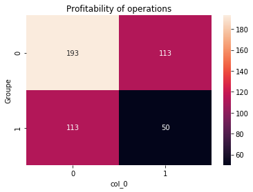

```python
# Application du Kmeans
from sklearn.cluster import KMeans
kmeans = KMeans(n_clusters = 2, init = "k-means++", max_iter = 300, n_init = 10, random_state = 0)
kmeans.fit(cible)
y_kmeans= kmeans.fit_predict(cible)
#correspondance les vrais labels avec les groupes de la CAH
plt.figure()
plt.title('Profitability of operations')

sns.heatmap(pd.crosstab(data_2.Groupe, kmeans.labels_), annot=True, fmt='d')
```

*Ce table de confusion va nous permettre de sortir des critères d’évaluation. on peut calculer les deux mesures les plus connues pour évaluer le model La sensibilité correspond donc au nombre d'opérations les moins rentables et positives au test (vrais positifs) parmi l'ensemble des opérations les moins rentables.

Sensibilité = TP/(TP+FN) = 193/(193+113) = 0.63 Une sensibilité de 0,63 signifie que, lorsque l'opération est non rentable, il y a 63% de chance que le test de dépistage de la rentabilité soit positif. Spécificité = TN/(TN+FP) = 50/(113+50) = 0.30 Une spécificité de 0,3 signifie que, lorsque l'opération est rentable, il y 30% de chance que le test de dépistage de la rentabilité soit négatif.

Maintenant passons au critère de bonne classification : TBC = (TP+TN)/Total = (193+50)/469=0.51 TBC(1)=193/(193+113) = 0.63 TBC(2)=50/(113+50)=0.30 KMEANS classifie mieux les opérations les moins rentables que les opérations les plus rentables.

```python
y_kmeans = kmeans.fit_predict(cible)
```

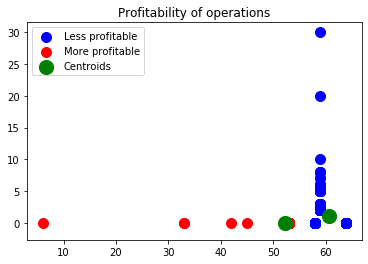

```python
plt.scatter(cible.values[y_kmeans == 0, 0], cible.values[y_kmeans == 0, 1], s = 100, c = 'blue', label = 'Less profitable')
plt.scatter(cible.values[y_kmeans == 1, 0], cible.values[y_kmeans == 1, 1], s = 100, c = 'red', label = 'More profitable')
plt.scatter(kmeans.cluster_centers_[:, 0], kmeans.cluster_centers_[:, 1], s = 200, c = 'green', label = 'Centroids')
plt.legend()
plt.title('Profitability of operations')
plt.show()
```

# 2/ CAH Method

```python
from scipy.cluster.hierarchy import dendrogram , linkage
import scipy.cluster.hierarchy as sch
import numpy as np
from matplotlib import pyplot as plt
```

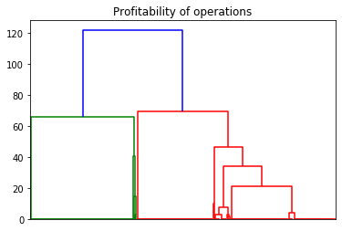

```python
Z = linkage(cible,method='ward',metric='euclidean')
#matérialisation des 2 classes (hauteur t=2)
plt.figure()
plt.title('Profitability of operations')
dendrogram(Z,no_labels=True)
plt.show()
```

La classification Ascendante Hiérarchique: Le dendrogramme décrit un ensemble de partitions imbriquées cohérentes, qui sont autant de solutions potentielles.

La méthode la plus pertinente dans la classification Ascendante Hiérarchique dans notre cas est La méthode de Ward. Elle est la mieux adaptée à nos données et notre objectif. Selon la méthode de Ward : Le dendrogramme « suggère » un découpage en 2 groupes selon la rentabilité des opérations, les « opérations moins rentables » ,colorées en vert, forme un groupe homogène. Cela s'explique par le fait que le bénéfice des opérations est faible ou presque nul. Par contre « opérations plus rentables », colorées en rouge, forment un groupe hétérogène. Ce groupe d'opérations est composé par plusieurs sous clusters. Cela s'explique par une grande variance entre les valeurs du bénéfice des opérations.

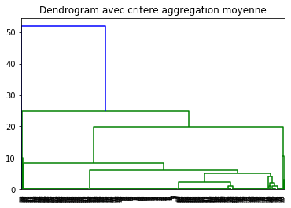

```python
# CAH avec méthode average et affichage du dendrogram
matrice1= linkage(cible, 'average')
dendrogram(matrice1)
plt.title('Dendrogram avec critere aggregation moyenne')
plt.show()
```

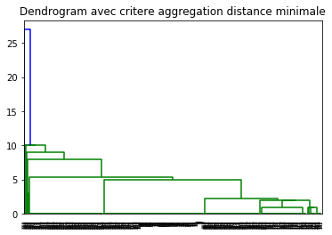

```python
# CAH avec méthode single et affichage du dendrogram
matrice2 = linkage(cible, 'single')
dendrogram(matrice2)
plt.title('Dendrogram avec critere aggregation distance minimale')
plt.show()
```

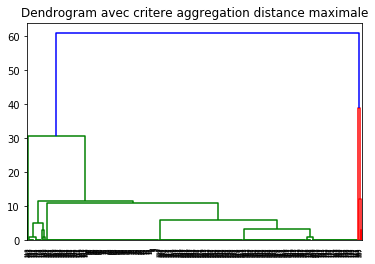

```python
# CAH avec méthode complete et affichage du dendrogram
matrice3=linkage(cible, 'complete')
dendrogram(matrice3)
plt.title('Dendrogram avec critere aggregation distance maximale')
plt.show()
```

```python
#Couper le dendrogramme
import scipy
Z = linkage(cible,method='ward',metric='euclidean')
groupes_cah = scipy.cluster.hierarchy.fcluster(Z,t=92.5,criterion='distance')
print(groupes_cah)
```

```
[1 1 1 1 1 1 1 1 1 1 1 1 1 1 1 1 1 1 1 1 1 1 1 1 1 1 1 1 1 1 1 1 1 1 1 1 1
 1 1 1 1 1 1 1 1 1 1 1 1 1 1 1 1 1 1 1 1 1 1 1 1 1 1 1 1 1 1 1 1 1 1 1 1 1
 1 1 1 1 1 1 1 1 1 1 1 1 1 1 1 1 1 1 1 1 1 1 1 1 1 1 1 1 1 1 1 1 1 1 1 1 1
 1 1 2 2 2 2 2 2 2 2 2 2 2 2 2 2 2 2 2 2 2 2 2 2 2 2 2 2 2 2 2 2 2 2 2 2 2
 2 2 2 2 2 2 2 2 2 2 2 2 2 2 2 2 2 2 2 2 2 2 2 2 2 2 2 2 2 2 2 2 2 2 2 2 2
 2 2 2 2 2 2 2 2 2 2 2 2 2 2 2 2 2 2 2 2 2 2 2 2 2 2 2 2 2 2 2 2 2 2 2 2 2
 2 2 2 2 2 2 2 2 2 2 2 2 2 2 2 2 2 2 2 2 2 2 2 2 2 2 2 2 2 2 2 2 2 2 2 2 2
 2 2 2 2 2 2 2 2 2 2 2 2 2 2 2 2 2 2 2 2 2 2 2 2 2 2 2 2 2 2 2 2 2 2 2 2 2
 2 2 2 2 2 2 2 2 2 2 2 2 2 2 2 2 2 2 2 2 2 2 2 2 2 2 2 2 2 2 2 2 2 2 2 1 1
 1 1 1 1 1 1 1 1 1 1 1 1 1 1 1 1 1 1 1 1 1 1 1 1 1 1 1 1 1 1 1 1 1 1 1 1 1
 1 1 1 1 1 1 1 1 1 1 1 2 2 2 2 2 2 2 2 2 2 2 2 2 2 2 2 2 2 2 2 2 2 2 2 2 2
 2 2 2 2 2 2 2 2 2 2 2 2 2 2 2 2 2 2 2 2 2 2 2 2 2 2 2 2 2 2 2 2 2 2 2 2 2
 2 2 2 2 2 2 2 2 2 2 2 2 2 2 2 2 2 2 2 2 2 2 2 2 2]
```

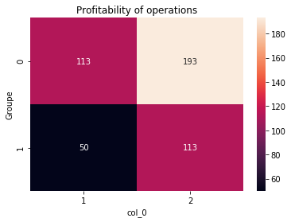

```python
#correspondance les vrais labels avec les groupes de la CAH
pd.crosstab(data_2.Groupe,groupes_cah)
plt.figure()
plt.title('Profitability of operations')

sns.heatmap(pd.crosstab(data_2.Groupe, groupes_cah), annot=True, fmt='d')
```

On peut déduire que notre CAH divise nos operationss en deux clusters tel que le cluster 1 represente les operations les moins rentable (113) et le cluster 2 les operations les plus rentable (113)

*Ce table de confusion va nous permettre de sortir les deux mesures les plus connues pour évaluer le model

Sensibilité = TP/(TP+FN) = 113/(113+50) = 0.69 Une sensibilité de 0,69 signifie que, lorsque l'opération est non rentable, il y a 69% de chance que le test de dépistage de la non rentabilité soit positif. Spécificité = TN/(TN+FP) = 113/(113+193) = 0.36

Une spécificité de 0,36 signifie que, lorsque l'opération est rentable, il y 36% de chance que le test de dépistage de la non rentabilité soit négatif.

Calcul de taux de bonne classification avec CAH : TBC = (TP+TN)/Total = (113+113)/469 =0.48  
TBC(kmeans) = 0.51 > TBC(cah)=0.48 L’algorithme de KMEANS est plus valable dans ce cas.